# Project Report

Python Princessess

Author

Avanti Parkhe, Ava Serin, Emily Zhang, and Ada Zhong

Published

May 23, 2023

Abstract

*This report aims to develop the most accurate predictions of median house value of Boston neighborhoods based on the features of each neighborhood. We developed ridge, lasso, decision tree, bagged decision trees, MARS, bagged MARS, random forest, XGBoost, and ensemble (voting and stacking) models. Our models were optimized for RMSE to penalize large errors and be sensitive to outliers. Ultimately, the best model was XGBoost, which returned a test RMSE of 2.709. Based on this model, we identified key recommendations to stakeholders. First, prospective homeowners should understand that areas with low-income residents and properties with lower average number of bedrooms are correlated with less expensive properties. Next, realtors and Boston housing authorities can better predict the fluctuations of house prices based on the trends in the aforementioned important features. That being said, stakeholders should be aware that our model may grow obsolete with time as the housing market changes in the future.*.

## 1 Background / Motivation

What motivated you to work on this problem?

Mention any background about the problem, if it is required to understand your analysis later on.

We were motivated to analyze this problem as we are college students nearing graduation who want to learn about what factors influence house prices, as finding housing after graduation is a complex process. One member of our group is interested in moving to Boston post-grad, so we figured this dataset would be fitting to our particular needs.

## 2 Problem statement

Describe your problem statement. Articulate your objectives using absolutely no jargon.

We are attempting to predict the median house price of Boston neighborhoods, in thousands of dollars, based on the characteristics of each neighborhood. This is a prediction problem because the response variable, `median_val`, is continuous and quantitative.

## 3 Data sources

What data did you use? Provide details about your data. Include links to data if you are using open-access data.

Our dataset is the Boston Housing Dataset. The dataset contains 14 columns, where `median_val` is the response variable. This corresponds to the median house price per neighborhood. This dataset was published by the University of Toronto’s Data for Evaluating Learning in Valid Experiments website. It contains housing information collected by the U.S Census Service regarding housing in the area of Boston. The dataset came as a `.tar.gz` file. We then converted this file into a csv file. The documentation and data are linked below.

https://www.cs.toronto.edu/~delve/data/boston/bostonDetail.html

## 4 Stakeholders

Who cares? If you are successful, what difference will it make to them?

Our primary stakeholders are current and prospective Boston residents, local realtors, and Boston housing authority. Our project will benefit current and prospective Boston residents because they will be able to better predict house prices and budget more efficiently. Local realtors will be able to market house prices more accurately and have better information on what houses to present to certain clients. The Boston housing authority can benefit by having more information on what neighborhoods have more affordable housing.

## 5 Data quality check / cleaning / preparation

Show the distribution of the response here. Report the standard deviation and mean in case of a regression problem, and proportion of 0s and 1s in case of classification.

For all other content, as mentioned below, just provide the highlights *(if any)* and put the details in the appendix.

In a tabular form, show the distribution of values of each variable used in the analysis - for both categorical and continuous variables. Distribution of a categorical variable must include the number of missing values, the number of unique values, the frequency of all its levels. If a categorical variable has too many levels, you may just include the counts of the top 3-5 levels.

Mention any useful insights you obtained from the data quality check that helped you develop the model or helped you realize the necessary data cleaning / preparation. Its ok if there were none.

Were there any potentially incorrect values of variables that required cleaning? If yes, how did you clean them? Were there missing values? How did you handle them? Its ok if the data was already clean.

Did you do any data wrangling or data preparation before the data was ready to use for model development? Did you create any new predictors from exisiting predictors? For example, if you have number of transactions and spend in a credit card dataset, you may create spend per transaction for predicting if a customer pays their credit card bill. Mention the steps at a broad level, you may put minor details in the appendix. Only mention the steps that ended up being useful towards developing your model(s).

|  | Variable | Type | Missing | Unique | Mean | Std | Min | Max |
| --- | --- | --- | --- | --- | --- | --- | --- | --- |
| 0 | crime_rate | float64 | 0 | 504 | 3.613524 | 8.601545 | 0.00632 | 88.9762 |
| 1 | zoned_land | float64 | 0 | 26 | 11.363636 | 23.322453 | 0.00000 | 100.0000 |
| 2 | nr_business | float64 | 0 | 76 | 11.136779 | 6.860353 | 0.46000 | 27.7400 |
| 3 | river | int64 | 0 | 2 | 0.069170 | 0.253994 | 0.00000 | 1.0000 |
| 4 | nitric_oxide | float64 | 0 | 81 | 0.554695 | 0.115878 | 0.38500 | 0.8710 |
| 5 | avg_rooms | float64 | 0 | 446 | 6.284634 | 0.702617 | 3.56100 | 8.7800 |
| 6 | prop_age | float64 | 0 | 356 | 68.574901 | 28.148861 | 2.90000 | 100.0000 |
| 7 | dist_emp | float64 | 0 | 412 | 3.795043 | 2.105710 | 1.12960 | 12.1265 |
| 8 | highway_acc | int64 | 0 | 9 | 9.549407 | 8.707259 | 1.00000 | 24.0000 |
| 9 | tax_rate | float64 | 0 | 66 | 408.237154 | 168.537116 | 187.00000 | 711.0000 |
| 10 | pt_ratio | float64 | 0 | 46 | 18.455534 | 2.164946 | 12.60000 | 22.0000 |
| 11 | race_prop | float64 | 0 | 357 | 356.674032 | 91.294864 | 0.32000 | 396.9000 |
| 12 | low_inc | float64 | 0 | 455 | 12.653063 | 7.141062 | 1.73000 | 37.9700 |
| 13 | median_val | float64 | 0 | 229 | 22.532806 | 9.197104 | 5.00000 | 50.0000 |

```
count    506.000000
mean      22.532806
std        9.197104
min        5.000000
25%       17.025000
50%       21.200000
75%       25.000000
max       50.000000
Name: median_val, dtype: float64
```

There were no missing values and no na values. The data was already clean.

The data preparation we did was dependent upon the model. The code is in the code file in the respective model sections. For the models that required a train, test split, (i.e. all of the models except Ridge, Lasso, Stepwise) we used the `train_test_split` feature of scikit learn with an 80/20 split of the train and test data. We used a `random_state` of 45. For the ridge, lasso, and stepwise models, we used np.random.seed to split the data into 80% training and 20% test. For ridge and lasso, we also did a log transformation on the response variable because there was a slight right skew in the data. More specific information can be found in the respective sections if any.

## 6 Exploratory data analysis

If there is any EDA that helped with model development, put it here. If EDA didn’t help then mention that, and you may show your EDA effort *(if any)* in the appendix.

List the insights (as bullet points), if any, you got from EDA that ended up being useful towards developing your final model.

If there are too many plots / tables, you may put them into appendix, and just mention the insights you got from them.

Note that you can write code to publish the results of the code, but hide the code using the yaml setting `#|echo: false`. For example, the code below makes a plot, but the code itself is not published with Quarto in the report.

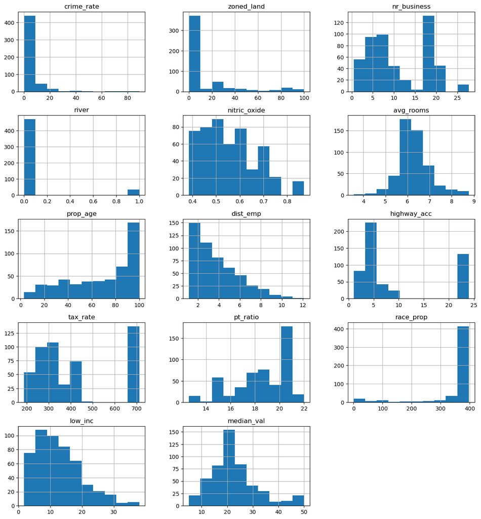

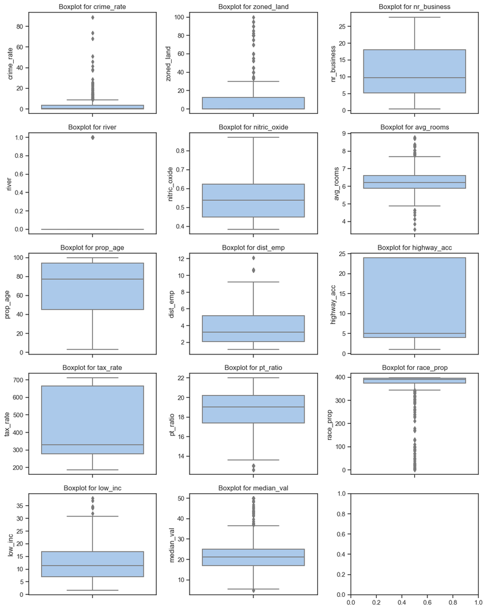

```
         feature       VIF
1     crime_rate  1.831537
2     zoned_land  2.352186
3    nr_business  3.992503
4          river  1.095223
5   nitric_oxide  4.586920
6      avg_rooms  2.260374
7       prop_age  3.100843
8       dist_emp  4.396007
9    highway_acc  7.808198
10      tax_rate  9.205542
11      pt_ratio  1.993016
12     race_prop  1.381463
13       low_inc  3.581585
14    median_val  3.855684
```

- From our VIF table, we found that none of the features in our dataset were collinear, so we knew that we did not have to drop features based on multicollinearity.
- While we conducted further EDA above, it did not aid model development.

## 7 Approach

What kind of a models did you use? What performance metric(s) did you optimize and why?

Is there anything unorthodox / new in your approach?

What problems did you anticipate? What problems did you encounter?

Did your problem already have solution(s) (posted on Kaggle or elsewhere). If yes, then how did you build upon those solutions, what did you do differently? Is your model better as compared to those solutions in terms of prediction accuracy or your chosen metric?

**Important: Mention any code repositories (with citations) or other sources that you used, and specifically what changes you made to them for your project.**

Our team sought to optimize our predictive model’s performance by using the root mean squared error (RMSE) as the metric of choice. RMSE is an effective tool for predicting Boston housing prices due to its ability to penalize large errors and its sensitivity to outliers. Both of these traits are critical, as substantial errors can lead to financial losses. Additionally, RMSE uses the same units as the response variable (in this case, thousands of dollars), which facilitates the interpretability of results for stakeholders. It should be noted that despite the existence of solutions on Kaggle for this dataset, we independently developed our models and sourced our dataset from an alternative location.

We started with a naive linear model as a baseline with an RMSE 5.214. Our modeling approach then included the creation and tuning of several models: MARS, bagged MARS, random forest, decision tree, bagged decision tree, ridge and lasso regressions, backward stepwise regression, XGBoost, and an ensemble model containing bagged decision trees, XGBoost, and random forest models, all with the goal of reducing the RMSE.

As we progressed, we encountered several challenges. We anticipated some, such as the long runtime associated with models like gradient boosting, which ultimately led to our decision to use the XGBoost model. However, other challenges were unexpected. We observed that some of the finely tuned models, such as the XGBoost and RandomForest and all tuning iterations for the unbagged decision tree models, exhibited poorer performance than we initially predicted. These experiences underscore the complexity and nuance involved in model selection and tuning.

## 8 Developing the model: Hyperparameter tuning

Every person must describe their hyperparameter tuning procedure. Show the grid of hyperparameter values over which the initial search was done *(you may paste your grid search / random search / any other search code)*, and the optimal hyperparameter values obtained. After getting the initial search results, how did you make decisions *(if any)* to further fine-tune your model. Did you do another grid / random search or did you tune hyperparameters sequentially? If you think you didn’t need any fine tuning after the initial results, then mention that and explain why.

Put each model in a section of its name and mention the name of the team-member tuning the model. Below is an example:

### 8.1 MARS, Bagged MARS, Ensemble Model

*By Avanti Parkhe*

I started by finding the optimal degree of a single MARS model by using this code:

```
degrees = range(1, 5)

cv = KFold(n_splits=5, random_state=1, shuffle=True)

mse_list = []

for degree in degrees:

    model = Earth(max_terms = 1000, max_degree=degree)

    mse = -cross_val_score(model, X_train, y_train, cv=5, scoring='neg_mean_squared_error').mean()

    mse_list.append(mse)

optimal_degree = degrees[mse_list.index(min(mse_list))]
```

After getting this optimal degree, I made a MARS model and printed the model summary and RMSE. After this, I chose to bag the MARS model with the average predictions of both 10 and 50 models. I did this using a for loop and taking the predictions of each model within the for loop. I then found the RMSE for these predictions and eventually concluded that the bagged MARS models with 50 models resulted in the lowest RMSE.

### 8.2 Random Forest

*By Ava Serin*

**Initial hyperparameter grid:**

```
param_distributions = {'n_estimators': [100, 200, 500, 1000],
                        'max_depth': [10, 20, 30, 40],
                        'max_features': [1.0, 'sqrt', 'log2'],
                        'min_samples_split': [2, 5, 10],
                        'min_samples_leaf': [1, 2, 4],
                        'bootstrap': [True, False]
                        }
```

**Randomized search code:**

```
rf_model = RandomForestRegressor(random_state=45)

cv = KFold(n_splits=5, shuffle=True, random_state=45)

random_search = RandomizedSearchCV(estimator=rf_model, param_distributions=param_distributions, n_iter=100, cv=cv, n_jobs=-1,scoring= 'neg_mean_squared_error', random_state=45)
```

**Optimal hyperparameter values obtained and their test RMSE:**

`Best hyperparameters: {'n_estimators': 1000, 'min_samples_split': 2,'min_samples_leaf': 1, 'max_features': 'sqrt', 'max_depth': 30, 'bootstrap': False}`

Test RMSE: 2.9490771849917916

**Next steps:**

Upon the completion of the initial RandomizedSearchCV, I conducted another phase of hyperparameter tuning. In this round, I utilized RandomizedSearchCV again, but this time with a finer grid that employed values of similar magnitude to those that were found optimal in the initial search. This approach was taken in the hope that it might result in a lower RMSE. I consciously decided against tuning hyperparameters individually, thereby steering clear of a greedy approach.

**Second tuning hyperparameter grid:**

```
param_grid = {'n_estimators': [800, 1000, 1200],
              'max_depth': [20, 30, 40],
              'max_features': ['sqrt'],
              'min_samples_split': [2, 3, 4],
              'min_samples_leaf': [1, 2, 3],
              'bootstrap': [False]}
```

**Randomized search code:**

I used the same code to conduct the `RandomizedSearchCV` as previously used.

**Optimal parameters and RMSE obtained:**

`Best hyperparameters: {'bootstrap': False, 'max_depth': 20, 'max_features': 'sqrt', 'min_samples_leaf': 1, 'min_samples_split': 2, 'n_estimators': 1200}`

Test RMSE: 2.924846214324899

**Next Steps:**

I resolved to conduct one final round of hyperparameter tuning, this time choosing values slightly below and above those identified as optimal in the previous round.

**Third and final tuning hyperparameter grid:**

```
param_grid = {'n_estimators': [1100, 1200, 1300],
              'max_depth': [15, 20, 25],
              'max_features': ['sqrt'],
              'min_samples_split': [2],
              'min_samples_leaf': [1],
              'bootstrap': [False]}
```

**Randomized search code:**

I used the same code to conduct the `RandomizedSearchCV` as previously used.

**Optimal parameters and RMSE obtained:**

`Best hyperparameters: {'bootstrap': False, 'max_depth': 20, 'max_features': 'sqrt', 'min_samples_leaf': 1, 'min_samples_split': 2, 'n_estimators': 1200}`

Test RMSE: 2.924846214324899

### 8.3 Decision Trees, Bagged Decision Trees

*By Ada Zhong*

I initially started by using a decision tree regressor, attempting to tune it, before bagging the decision trees.

Naive Decision Tree

```
dt = DecisionTreeRegressor(random_state=45)
```

Test RMSE: 4.028

Coarse Grid Search for Decision Tree

```
parameters = {'max_depth':range(2, 19, 2),
              'max_leaf_nodes':range(2, 385, 50),
              'min_samples_leaf':range(1, 5),
              'max_features': [1.0, 'sqrt', 'log2'],
              'min_samples_split': [2, 5, 10],
              'min_samples_leaf': [1, 2, 4],
              'min_weight_fraction_leaf': np.arange(0,0.5,0.1)
             }

cv = KFold(n_splits=5, shuffle=True, random_state=1)

grid_dt = GridSearchCV(dt, parameters, n_jobs=-1,verbose=1,cv=cv, scoring=['neg_mean_absolute_error', 'r2'],
refit='neg_mean_absolute_error')
```

This returned optimal hyperparameters:

```
{'max_depth': 10, 'max_features': 1.0, 'max_leaf_nodes': 52, 'min_samples_leaf': 2, 'min_samples_split': 10,'min_weight_fraction_leaf': 0.0}
```

Fine Grid Search for Decision Tree

```
parameters = {'max_depth':range(2, 19, 2),
              'max_leaf_nodes':range(2, 100),
              'min_samples_leaf':range(1, 5),
              'max_features': [1.0, 'sqrt', 'log2'],
              'min_samples_split': [2, 5, 10],
              'min_samples_leaf': [1, 2, 4],
              'min_weight_fraction_leaf': np.arange(0,0.5,0.1)
             }

cv = KFold(n_splits=5, shuffle=True, random_state=1)

grid_dt = GridSearchCV(dt, parameters, n_jobs=-1,verbose=1,cv=cv, scoring=['neg_mean_absolute_error', 'r2'], refit='neg_mean_absolute_error')
```

This returned optimal hyperparameters:

```
{'max_depth': 12, 'max_features': 1.0, 'max_leaf_nodes': 55, 'min_samples_leaf': 2, 'min_samples_split': 10, 'min_weight_fraction_leaf': 0.0}
```

and a tuned decision tree RMSE of 4.044. Although I did multiple fine grid searches, I could not obtain an RMSE lower than 4.028 (from the naive decision tree), so I chose to bag the naive decision tree.

Naive Bagged Trees

```
bagged_trees = BaggingRegressor(dt, random_state=45).fit(X_train, y_train)
```

Bagged trees RMSE: 3.401164160557209

Grid Search for Bagged Trees

```
params = {'base_estimator': [dt],
          'max_samples': [0.5, 0.6, 0.7, 0.8, 0.9, 1.0],
          'max_features': [0.3, 0.5, 0.7, 1.0],
          'bootstrap': [True, False],
          'bootstrap_features': [True, False]}

cv = KFold(n_splits=5, shuffle=True, random_state=45)

bagging_regressor_grid = GridSearchCV(bagged_trees,
                                      param_grid=params, cv=cv, n_jobs=-1, verbose=1,
                                      scoring = 'neg_mean_absolute_error')
```

This returned optimal hyperparameters:

```
{'base_estimator': DecisionTreeRegressor(random_state=45), 'bootstrap': False, 'bootstrap_features': False, 'max_features': 1.0, 'max_samples': 0.8}
```

I then used `n_estimators = 150` and obtained a tuned bagged trees RMSE of 3.173. Since this was a significant decrease in RMSE from my optimal decision tree and my naive bagged trees, I focused on sequentially adjusting the model’s hyperparameters (particularly n_estimators) as opposed to conducting multiple fine grid searches so as to decrease runtime. I ended up sticking with the hyperparameters from the grid search and using `n_estimators = 150`.

### 8.4 Ridge, Lasso, Stepwise Selection, XGBoost

*By Emily Zhang*

**Ridge**

I split the data into 80-20 train test. I did a log transformation of the data and standardized the predictors. I optimized the tuning parameter lambda on this space:

`alphas = 10**np.linspace(10,-2,200)*0.5`

The optimal value of the tuning parameter I obtained was `ridgecv.alpha_ = 3.492939873392624`.

RMSE Ridge: 3.2744798634008294

Ridge coef: [-0.08918515 0.03162475 0.01700329 0.02538032 -0.09862914 0.06401858 0.01102414 -0.10396571 0.10370713 -0.08653053 -0.07895877 0.03298307 -0.2092435 ]

**Lasso**

I split the data into 80-20 train test. I did a log transformation of the data and standardized the predictors. I optimized the tuning parameter lambda on this space:

`alphas = 10**np.linspace(10,-2,100)*0.1`

The optimal value of the tuning parameter I obtained was `lassocv.alpha_ = 5e-06`

Lasso RMSE: 3.2801703532207425

Lasso coef: [-0.09154541 0.03393505 0.0224902 0.02462967 -0.10381835 0.06114907 0.01301798 -0.10740441 0.11741107 -0.09925511 -0.08091326 0.03242871 -0.21309302]

Lasso performs its own variable selection.

**Backward Stepwise Selection**

I split the data into 80-20 train test. Based on the BIC, I used 10 predictors: `crime_rate, river, nitric_oxide, avg_rooms, dist_emp, highway_acc, tax_rate, pt_ratio, race_prop, low_inc`.

Backward Stepwise Selection RMSE: 3.2487002208385203

**XGBoost**

I used the same train and test dataset as the models from my teammates, train-test split of 80/20. I used a KFold object for the cv parameter to perform a randomized hyperparameter search using cross-validation with 2 folds. I did an initial coarse grid search on the following parameter grid:

```
xgb = XGBRegressor(random_state=45)
param_grid = {'max_depth':[4,6,8],
              'n_estimators':[800, 1000, 1200],
              'learning_rate':[0.1,0.25,0.5],
              'reg_lambda':[0,1,10],
              'gamma':[0,10],
              'subsample':[0.4,0.45,0.5]
             }
```

Randomized search:

```
cv = KFold(n_splits=2, shuffle=True, random_state=1)

grid = RandomizedSearchCV(xgb, param_grid, n_jobs=-1,verbose=1,cv=cv, scoring='neg_mean_absolute_error', random_state = 45)
```

After fitting the data, I obtained the following best hyperparameters: `{'subsample': 0.5, 'reg_lambda': 10, 'n_estimators': 1200, 'max_depth': 6, 'learning_rate': 0.1, 'gamma': 10}`

Test RMSE: 3.05080608751799

Next, from my experience working on Assignment D, a random_state of 1 produces lower results for RMSE so I did a further coarse grid search on the same parameter grid but changed the `random_state` value in the `RandomizedSearchCV` to 1 (changed from 45).

```
xgb = XGBRegressor(random_state=45)

param_grid = {'max_depth':[4,6,8],
              'n_estimators':[800, 1000, 1200],
              'learning_rate':[0.1,0.25,0.5],
              'reg_lambda':[0,1,10],
              'gamma':[0,10],
              'subsample':[0.4,0.45,0.5]
             }
```

Randomized search:

```
cv = KFold(n_splits=2, shuffle=True, random_state=1)

grid = RandomizedSearchCV(xgb, param_grid, n_jobs=-1,verbose=1,cv=cv, scoring='neg_mean_absolute_error', random_state = 1)
```

After fitting the data, I obtained the following optimal hyperparameters: `{'subsample': 0.5, 'reg_lambda': 1, 'n_estimators': 1200, 'max_depth': 8, 'learning_rate': 0.1, 'gamma': 10}`

Test RMSE: 2.709290310082389

The most important predictor was percentage of low income residents and the least important predictor was proportion of residential land zoned for lots over 25,000 sq. ft.

I attempted some further fine-tuning of the model:

```
xgb = XGBRegressor(random_state=45)

param_grid = {'max_depth':[4,6,8,10],
              'n_estimators':[1000, 1200, 1400],
              'learning_rate':[0.03, 0.05, 0.07, 0.1],
              'reg_lambda':[0,1,2],
              'gamma':[8, 9,10],
              'subsample':[0.45, 0.5, 0.55]
             }

cv = KFold(n_splits=2, shuffle=True, random_state=1)

grid = RandomizedSearchCV(xgb, param_grid, n_jobs=-1,verbose=1,cv=cv, scoring='neg_mean_absolute_error', random_state = 1)
```

Best hyperparameters: `{'subsample': 0.45, 'reg_lambda': 1, 'n_estimators': 1400, 'max_depth': 4, 'learning_rate': 0.05, 'gamma': 8}`

Test RMSE: 2.822496981169104

Seeing as the fine tuning did not help reduce the RMSE, we concluded that further fine-tuning was not necessary. This along with the fact that the XGBoost model obtained with coarse grid searching was the lowest RMSE led to our decision to keep the model as is.

## 9 Model Ensemble

*By Avanti Parkhe*

Put the results of enembling individual models. Feel free to add subsections in this section to add more innovative ensembling methods.

**Voting ensemble**

We did a simple voting ensemble with equal weights that returned an RMSE of 2.796. We then chose to go with stacking ensembles for the RMSE. In order to tune this model, I used the previous models that had been tuned with the best hyperparameters. These were the individual models used, with the hyperparameters obtained from previous tunings done by others.

```
model_rf = RandomForestRegressor(n_estimators=1200, max_depth=20, max_features='sqrt', min_samples_split=2,
                             min_samples_leaf=1, bootstrap=False,random_state=45).fit(X_train, y_train)
dt = DecisionTreeRegressor(random_state=45)
dt.fit(X_train, y_train)
model_dt = BaggingRegressor(base_estimator=dt, random_state=45, n_jobs=-1, n_estimators=150, max_features=1.0,
                        max_samples=0.8,bootstrap=False, bootstrap_features=False)
model_xgb = XGBRegressor(random_state = 1, max_depth = 8, learning_rate = 0.1,
                    n_estimators = 1200,reg_lambda = 1, gamma = 10, subsample = 0.5).fit(X_train, y_train)
```

**Stacking ensemble**

We did 3 different models as the metamodel for the Stacking ensemble: Linear Regression, Lasso, and MARS. The Linear Regression metamodel returned a RMSE of 2.772. The Lasso metamodel returned a RMSE of 2.767, and the MARS metamodel returned an RMSE of 2.908. The models that were used in the Stacking ensemble were the same as the ones used above. For each of the metamodels, there was a different input in final_estimator.

**Ensemble of ensembled models**

Ensembling of all stacking regressor models resulted in an RMSE of 2.732. This model was not tuned; the 3 different metamodels of the Stacking ensemble were used.

## 10 Limitations of the model with regard to prediction

Are you confident that you found the optimal hyperparameter values for each of your individual models, and that your individual models cannot be better tuned? Or, are there any models that could be better tuned if you had more time / resources, but you are limited by the amount of time you can spend on the course project *(equivalent to one assignment)*? If yes, then which models could be better tuned and how?

Will it be possible / convenient / expensive for the stakeholders to collect the data relating to the predictors in the model. Using your model, how soon will the stakeholder be able to predict the outcome before the outcome occurs. For example, if the model predicts the number of bikes people will rent in Evanston on a certain day, then how many days before that day will your model be able to make the prediction. This will depend on how soon the data that your model uses becomes available. If you are predicting election results, how many days / weeks / months / years before the election can you predict the results.

When will your model become too obsolete to be useful?

While we hold considerable confidence in having discovered optimal hyperparameter values, the nature of using `RandomizedSearchCV` for tuning—coupled with our own informed assumptions on the starting points for the searches and the strategy to fine-tune our models—leaves some room for uncertainty. Moreover, due to time constraints and computational expenses, we had to forego consideration of several models including AdaBoost, GradientBoost, CatBoost, and Bagged Random Forest, to name a few. Specifically for our ensemble model, we employed a greedy strategy, tuning each model individually rather than optimizing the ensemble as a cohesive whole.

The task of data collection, albeit straightforward in theory, has its practical challenges. It’s feasible to gather information from resources like the US Census and local government databases, but the frequency and ease of data collection can vary greatly among different predictors. For instance, the US Census is carried out every ten years, rendering information such as household income and racial proportions in Boston-area towns sporadically updated. Given the volatility of the housing market, relying on these parameters for accurate housing price prediction seems implausible. However, other predictors like proximity to the Charles River and nitric oxide concentration have more frequently updated and readily available data, making them reliable predictors.

The dataset we used hails from 1996, predating the 2008 U.S. housing crisis. Considering the substantial fluctuations in housing prices due to factors like inflation, this model may already be outdated in its specific accuracy of predicting current housing prices. Despite this, it does offer valuable insights into the key features involved in predicting housing prices, which could retain their relevance even today.

## 11 Conclusions and Recommendations to stakeholder(s)

What conclusions do you draw based on your model? You may draw conclusions based on prediction accuracy, or other performance metrics.

How do you use those conclusions to come up with meaningful recommendations for stakeholders? The recommendations must be action-items for stakeholders that they can directly implement without any further analysis. Be as precise as possible. The stakeholder(s) are depending on you to come up with practically implementable recommendations, instead of having to think for themselves.

If your recommendations are not practically implementable by stakeholders, how will they help them? Is there some additional data / analysis / domain expertise you need to do to make the recommendations implementable?

Do the stakeholder(s) need to be aware about some limitations of your model? Is your model only good for one-time use, or is it possible to update your model at a certain frequency (based on recent data) to keep using it in the future? If it can be used in the future, then for how far into the future?

Based on our model development, XGBoost is the optimal regressor with a test RMSE of 2.709. From this final model, the features stakeholders must pay attention to most if they are concerned with median house prices by neighborhood are `low_inc`, `avg_rooms`, and `nitric_oxide`. That being said, stakeholders should be aware of the fact that our model may grow obsolete with time, as specified in the previous section, though it can still be used for recent data. A new model based on housing in the 21st century would have to be developed to continue predicting median house price by neighborhood accurately, and it is unclear whether this new model would contain the same feature importances.

For prospective Boston homeowners/residents, they should understand that proportion of low income residents and properties with lower average number of bedrooms are correlated with the least expensive properties. As such, when searching for places to live on platforms such as Zillow or Boston Pads, these individuals should filter for homes that contain the maximum number of bedrooms they are interested in. While income information is harder to come by, they can Google the average income of Boston neighborhoods or review Census data.

Realtors and the Boston Housing Authority should understand that the aforementioned most important features are critical in predicting house prices. As such, they should monitor current companies that are developing properties in Boston and see if these organizations are trending more towards family homes, apartments, duplexes, etc. as these are associated with the number of rooms per dwelling. They should also monitor trends in employment, neighborhood demographics, education, etc. as these are all associated with the income of residents. The only domain expertise that may be missing for finding information on nitric oxide concentration; here, they may have to seek out scientific government authorities to find the most up-to-date statistics.

That being said, stakeholders wanting accurate predictions on median house values should take a bigger picture view that does not solely focus on the predictors in this dataset. The state of the economy, local and national politics, distance to educational institutions, etc. are all critical predictors. Ultimately, while we were able to reduce our RMSE significantly from our first, naive linear regression, there are a multitude of factors at play in this problem.

Add details of each team member’s contribution, other than the models contributed, in the table below.

## Individual contribution

| Team member | Individual Model | Work other than individual model | Details of work other than individual model |
| --- | --- | --- | --- |
| Avanti Parkhe | Mars, Bagged Mars | Ensembling | Did voting, stacking, and ensembling of ensembling |
| Ava Serin | Random Forest | EDA, report | Looked at distributions of variables with supervision from other team members; wrote limitations and approach sections. |
| Emily Zhang | Ridge, Lasso, Stepwise Selection, XGBoost | Report | Wrote data sources and data cleaning, model development |
| Ada Zhong | Decision Trees, Bagged Decision Trees | Report | Wrote abstract, background/motivation, problem statement, model development, and conclusions |

## References

No references beside dataset used (https://www.cs.toronto.edu/~delve/data/boston/bostonDetail.html).